# IE 423 Project Part 2

Elif Melisa Avcı - 2019402108

Doğa Yıldız - 2019402099

Zümra İnci - 2019402090

# Introduction

When we merge the data, we made linear interpolation for empty cells:

```python
import pandas as pd
import numpy as np
import os
from itertools import combinations
from sklearn.linear_model import LinearRegression
import matplotlib.pyplot as plt

sigma_mult = 2

csv_files = ['/Users/x/Desktop/20180101_20231121_bist30/20201228_20210328_bist30.csv',
              '/Users/x/Desktop/20180101_20231121_bist30/20210329_20210627_bist30.csv',
              '/Users/x/Desktop/20180101_20231121_bist30/20210628_20210926_bist30.csv',
              '/Users/x/Desktop/20180101_20231121_bist30/20210927_20211226_bist30.csv',
              '/Users/x/Desktop/20180101_20231121_bist30/20211227_20220327_bist30.csv',
              '/Users/x/Desktop/20180101_20231121_bist30/20220328_20220626_bist30.csv',
              '/Users/x/Desktop/20180101_20231121_bist30/20220627_20220925_bist30.csv',
              '/Users/x/Desktop/20180101_20231121_bist30/20220926_20221225_bist30.csv',
              '/Users/x/Desktop/20180101_20231121_bist30/20221226_20230326_bist30.csv']

# Combine CSV files and make linear interpolation for empty cells
def combine_csv(files):
    all_data = pd.DataFrame()
    for file in files:
        df = pd.read_csv(file, parse_dates=['timestamp'], index_col='timestamp')
        all_data = pd.concat([all_data, df])
    all_data.sort_index(inplace=True)  # Ensure the data is sorted by time
    all_data.interpolate(method='linear', inplace=True)  # Interpolate missing values
    return all_data

stock_data = combine_csv(csv_files)
```

Then we calculate the correlations of each pair of the companies. First ten company pairs that have the highest correlations are:

```python
# Correlations
def calculate_correlations(df):
    pivot_df = df.pivot(columns='short_name', values='price').dropna()
    return pivot_df.corr()

correlation_matrix = calculate_correlations(stock_data)

def top_correlated_pairs(corr_matrix, num_pairs=10):
    corr_pairs = corr_matrix.unstack().sort_values(kind="quicksort", ascending=False)
    return corr_pairs[corr_pairs != 1].drop_duplicates().head(num_pairs)

print("Top 10 Correlated Pairs:")
print(top_correlated_pairs(correlation_matrix))
```

```
Top 10 Correlated Pairs:
short_name  short_name
KCHOL       SAHOL         0.993490
THYAO       PGSUS         0.991765
SISE        SAHOL         0.991637
AKBNK       YKBNK         0.991555
            ISCTR         0.990752
EKGYO       DOHOL         0.990197
SISE        KCHOL         0.989591
TUPRS       KCHOL         0.989561
ASELS       TTKOM         0.989244
SISE        TUPRS         0.989156
dtype: float64
```

We choose the following pairs:

- KCHOL and SAHOL --> Corr = 0.9935
- AKBNK and YKBNK --> Corr = 0.9915

We construct a function that can fit a linear regression model. In this case, X is the independent variable, y is the dependent variable. So, the model fitting a line that best predicts the price of y (in first pair SAHOL), based on the price of X (in this case, KCHOL). Then we calculate the residuals, with def calculate_residuals function. The residuals calculated in the function are the differences between the actual observed prices of 'SAHOL' and the prices predicted by the model from 'KCHOL' prices within the specified range.

```python
stock1 = 'KCHOL'
stock2 = 'SAHOL'

def linear_regression_model(df, stock1, stock2):
    X = df[df['short_name'] == stock1]['price'].values.reshape(-1, 1)
    y = df[df['short_name'] == stock2]['price'].values
    model = LinearRegression().fit(X, y)
    return model

model = linear_regression_model(stock_data, stock1, stock2)

def calculate_residuals(df, model, start_date, end_date):
    filtered_df = df[(df.index >= start_date) & (df.index <= end_date)]
    X = filtered_df[filtered_df['short_name'] == stock1]['price'].values.reshape(-1, 1)
    y_actual = filtered_df[filtered_df['short_name'] == stock2]['price'].values
    y_predicted = model.predict(X)
    residuals = y_actual - y_predicted
    return residuals, filtered_df

residuals, filtered_data = calculate_residuals(stock_data, model, '2023-01-01', '2023-03-31')
```

We plotted the control chart for residuals to check if the trading signals are correct with the following plot function.

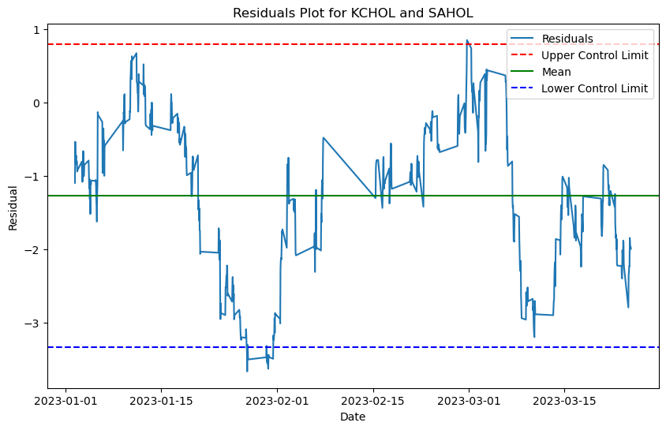

```python
# Plotting residuals with control limits
def plot_residuals_with_control_limits(residuals, filtered_data, ucl ,lcl):
    plt.figure(figsize=(10, 6))
    plt.plot(filtered_data[filtered_data['short_name'] == stock2].index, residuals, label='Residuals')
    plt.axhline(y=upper_control_limit, color='r', linestyle='--', label='Upper Control Limit')
    plt.axhline(y=mean_residual, color='g', linestyle='-', label='Mean')
    plt.axhline(y=lower_control_limit, color='b', linestyle='--', label='Lower Control Limit')
    plt.title(f'Residuals Plot for {stock1} and {stock2}')
    plt.xlabel('Date')
    plt.ylabel('Residual')
    plt.legend()
    plt.show()

mean_residual = np.mean(residuals)
std_residual = np.std(residuals)
upper_control_limit = mean_residual + sigma_mult * std_residual
lower_control_limit = mean_residual - sigma_mult * std_residual

plot_residuals_with_control_limits(residuals, filtered_data, upper_control_limit, lower_control_limit)
```

```python
# BUY or SELL signals
def generate_trading_signals(filtered_data, residuals):
    signals = []
    stock1_data = filtered_data[filtered_data['short_name'] == stock1]
    stock2_data = filtered_data[filtered_data['short_name'] == stock2]

    for index, residual in enumerate(residuals):
        timestamp = stock1_data.index[index]
        stock1_price = stock1_data['price'].iloc[index]
        stock2_price = stock2_data['price'].iloc[index]

        if residual > upper_control_limit:
            signals.append((timestamp, stock1_price, 'BUY', stock2_price, 'SELL'))
        elif residual < lower_control_limit:
            signals.append((timestamp, stock1_price, 'SELL', stock2_price, 'BUY'))
    return signals

trading_signals = generate_trading_signals(filtered_data, residuals)

print(f"{'Date':<12} {'Hour':<8} {'KCHOL Price':<12} {'KCHOL Decision':<15} {'SAHOL Price':<12} {'SAHOL Decision'}")
for signal in trading_signals:
    date_str = signal[0].date().strftime('%Y-%m-%d')
    time_str = signal[0].time().strftime('%H:%M:%S')
    print(f"{date_str:<12} {time_str:<8} {signal[1]:<12.2f} {signal[2]:<15} {signal[3]:<12.2f} {signal[4]}")
```

```
Date         Hour     KCHOL Price  KCHOL Decision  SAHOL Price  SAHOL Decision
2023-01-27   12:00:00 76.19        SELL            37.66        BUY
2023-01-27   13:00:00 76.09        SELL            37.56        BUY
2023-01-27   14:00:00 77.26        SELL            37.94        BUY
2023-01-27   17:00:00 77.36        SELL            38.19        BUY
2023-01-27   18:00:00 77.31        SELL            38.13        BUY
2023-01-30   09:00:00 77.36        SELL            38.19        BUY
2023-01-30   11:00:00 77.46        SELL            38.19        BUY
2023-01-30   12:00:00 77.36        SELL            38.23        BUY
2023-01-30   13:00:00 77.41        SELL            38.13        BUY
2023-01-30   14:00:00 76.48        SELL            37.70        BUY
2023-01-30   15:00:00 76.43        SELL            37.56        BUY
2023-01-30   16:00:00 77.07        SELL            37.87        BUY
2023-01-30   17:00:00 76.24        SELL            37.58        BUY
2023-01-30   18:00:00 76.19        SELL            37.52        BUY
2023-01-31   09:00:00 75.80        SELL            37.27        BUY
2023-02-28   18:00:00 75.85        BUY             41.65        SELL
```

We identified the initial capital 100,000 TL. When a buy signal occurs, we use all the capital to buy that stock until a sell signal occurs. Then, the profit or loss is calculated by final_portfolio_value - initial_capital at the end of simulation time.

```python
# Function to simulate the trading based on signals
def simulate_trading(signals, initial_capital):
    capital = initial_capital
    sahol_shares = 0
    kchol_shares = 0
    current_stock = None  # Track which stock is currently being held

    for signal in signals:
        date, kchol_price, kchol_decision, sahol_price, sahol_decision = signal

        if current_stock is None:
            # First signal: decide which stock to buy initially
            if sahol_decision == 'BUY':
                sahol_shares = capital // sahol_price
                capital -= sahol_shares * sahol_price
                current_stock = 'SAHOL'
            elif kchol_decision == 'BUY':
                kchol_shares = capital // kchol_price
                capital -= kchol_shares * kchol_price
                current_stock = 'KCHOL'

        else:
            # Subsequent signals: execute trades based on the current stock
            if current_stock == 'SAHOL' and kchol_decision == 'BUY':
                # Sell SAHOL and buy KCHOL
                capital += sahol_shares * sahol_price
                sahol_shares = 0
                kchol_shares = capital // kchol_price
                capital -= kchol_shares * kchol_price
                current_stock = 'KCHOL'

            elif current_stock == 'KCHOL' and sahol_decision == 'BUY':
                # Sell KCHOL and buy SAHOL
                capital += kchol_shares * kchol_price
                kchol_shares = 0
                sahol_shares = capital // sahol_price
                capital -= sahol_shares * sahol_price
                current_stock = 'SAHOL'

    # Calculate final value of the portfolio
    final_portfolio_value = capital + sahol_shares * sahol_price + kchol_shares * kchol_price
    profit_or_loss = final_portfolio_value - initial_capital
    return profit_or_loss

# Use the trading signals generated in your existing code
profit_or_loss = simulate_trading(trading_signals, 100000)

print(f"Profit or Loss at the end of the simulation: {profit_or_loss}₺")
```

```
Profit or Loss at the end of the simulation: 10606.9905₺
```

We apply the same simulation to the another pair of companies: AKBNK and YKBNK.

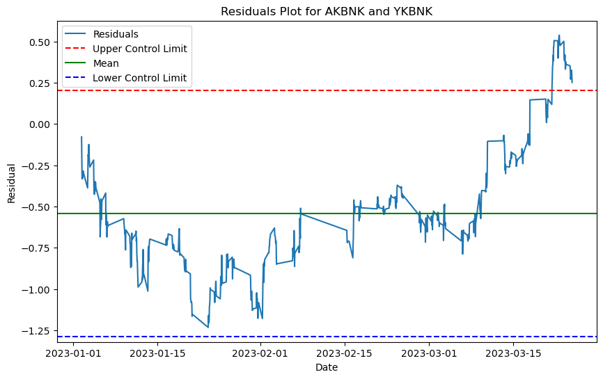

```python
stock1 = 'AKBNK'
stock2 = 'YKBNK'
model = linear_regression_model(stock_data, stock1, stock2)
residuals, filtered_data = calculate_residuals(stock_data, model, '2023-01-01', '2023-03-31')
mean_residual = np.mean(residuals)
std_residual = np.std(residuals)
upper_control_limit = mean_residual + sigma_mult * std_residual
lower_control_limit = mean_residual - sigma_mult * std_residual

plot_residuals_with_control_limits(residuals, filtered_data, upper_control_limit, lower_control_limit)
```

```python
trading_signals = generate_trading_signals(filtered_data, residuals)

print(f"{'Date':<12} {'Hour':<8} {'AKBNK Price':<12} {'AKBNK Decision':<15} {'YKBNK Price':<12} {'YKBNK Decision'}")
for signal in trading_signals:
    date_str = signal[0].date().strftime('%Y-%m-%d')
    time_str = signal[0].time().strftime('%H:%M:%S')
    print(f"{date_str:<12} {time_str:<8} {signal[1]:<12.2f} {signal[2]:<15} {signal[3]:<12.2f} {signal[4]}")
```

```
Date         Hour     AKBNK Price  AKBNK Decision  YKBNK Price  YKBNK Decision
2023-03-21   10:00:00 16.24        BUY             10.21        SELL
2023-03-21   11:00:00 16.28        BUY             10.28        SELL
2023-03-21   12:00:00 15.97        BUY             10.14        SELL
2023-03-21   13:00:00 16.10        BUY             10.24        SELL
2023-03-21   14:00:00 16.10        BUY             10.30        SELL
2023-03-21   15:00:00 16.30        BUY             10.40        SELL
2023-03-21   16:00:00 16.41        BUY             10.56        SELL
2023-03-21   17:00:00 16.01        BUY             10.29        SELL
2023-03-21   18:00:00 15.96        BUY             10.29        SELL
2023-03-22   09:00:00 16.05        BUY             10.35        SELL
2023-03-22   10:00:00 16.09        BUY             10.27        SELL
2023-03-22   11:00:00 16.22        BUY             10.41        SELL
2023-03-22   12:00:00 16.12        BUY             10.39        SELL
2023-03-22   13:00:00 16.16        BUY             10.44        SELL
2023-03-22   14:00:00 16.06        BUY             10.39        SELL
2023-03-22   15:00:00 16.06        BUY             10.39        SELL
2023-03-22   16:00:00 16.25        BUY             10.48        SELL
2023-03-22   17:00:00 16.24        BUY             10.47        SELL
2023-03-22   18:00:00 16.27        BUY             10.47        SELL
2023-03-23   09:00:00 16.19        BUY             10.44        SELL
2023-03-23   10:00:00 16.47        BUY             10.53        SELL
2023-03-23   11:00:00 16.42        BUY             10.49        SELL
2023-03-23   12:00:00 16.33        BUY             10.42        SELL
2023-03-23   13:00:00 16.35        BUY             10.47        SELL
2023-03-23   14:00:00 16.32        BUY             10.44        SELL
2023-03-23   15:00:00 16.33        BUY             10.37        SELL
2023-03-23   16:00:00 16.32        BUY             10.37        SELL
2023-03-23   17:00:00 16.58        BUY             10.58        SELL
2023-03-23   18:00:00 16.61        BUY             10.59        SELL
2023-03-24   09:00:00 16.67        BUY             10.62        SELL
2023-03-24   10:00:00 16.72        BUY             10.65        SELL
2023-03-24   11:00:00 16.58        BUY             10.53        SELL
2023-03-24   12:00:00 16.57        BUY             10.47        SELL
2023-03-24   13:00:00 16.51        BUY             10.45        SELL
2023-03-24   14:00:00 16.36        BUY             10.34        SELL
2023-03-24   15:00:00 16.46        BUY             10.42        SELL
2023-03-24   16:00:00 16.46        BUY             10.45        SELL
2023-03-24   17:00:00 16.33        BUY             10.32        SELL
2023-03-24   18:00:00 16.33        BUY             10.29        SELL
```

```python
# Use the trading signals generated in your existing code
profit_or_loss = simulate_trading(trading_signals, 100000)

print(f"Profit or Loss at the end of the simulation: {profit_or_loss}₺")
```

```
Profit or Loss at the end of the simulation: 558.4399000000121₺
```

# Task 2

For task 2, we apply time series analysis for the same pair of companies.

```python
import statsmodels.api as sm

stock1 = 'KCHOL'
stock2 = 'SAHOL'

# Perform time series analysis
def time_series_analysis(df, stock1, stock2):
    X = df[df['short_name'] == stock1]['price'].values.reshape(-1, 1)
    y = df[df['short_name'] == stock2]['price'].values

    model = LinearRegression().fit(X, y)

    residuals = y - model.predict(X)

    # Time series modeling (ARIMA)
    ts_model = sm.tsa.ARIMA(residuals, order=(1, 0, 1)).fit()

    forecasted_residuals = ts_model.predict(start=len(residuals), end=len(residuals) + len(X) - 1)

    mean_residual = np.mean(residuals)
    std_residual = np.std(residuals)
    updated_control_limits = (mean_residual + sigma_mult * std_residual, mean_residual - sigma_mult * std_residual)

    return model, updated_control_limits

new_model, new_control_limits = time_series_analysis(stock_data, stock1, stock2)
```

```python
def calculate_residuals(df, model, start_date, end_date):
    filtered_df = df[(df.index >= start_date) & (df.index <= end_date)]
    X = filtered_df[filtered_df['short_name'] == stock1]['price'].values.reshape(-1, 1)
    y_actual = filtered_df[filtered_df['short_name'] == stock2]['price'].values
    y_predicted = model.predict(X)
    residuals = y_actual - y_predicted
    return residuals, filtered_df

new_residuals, new_filtered_data = calculate_residuals(stock_data, new_model, '2023-01-01', '2023-03-31')
```

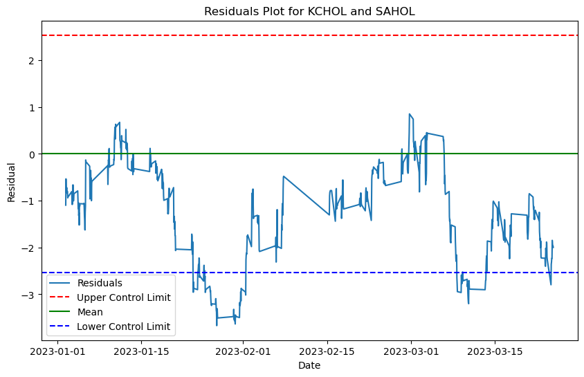

```python
# Plotting residuals with control limits
def plot_residuals_with_control_limits(residuals, filtered_data, control_limits):
    plt.figure(figsize=(10, 6))
    plt.plot(filtered_data[filtered_data['short_name'] == stock2].index, residuals, label='Residuals')
    plt.axhline(y=control_limits[0], color='r', linestyle='--', label='Upper Control Limit')
    plt.axhline(y=0, color='g', linestyle='-', label='Mean')
    plt.axhline(y=control_limits[1], color='b', linestyle='--', label='Lower Control Limit')
    plt.title(f'Residuals Plot for {stock1} and {stock2}')
    plt.xlabel('Date')
    plt.ylabel('Residual')
    plt.legend()
    plt.show()

plot_residuals_with_control_limits(new_residuals, new_filtered_data, new_control_limits)
```

```python
def generate_trading_signals(filtered_data, residuals, control_limits):
    signals = []
    stock1_data = filtered_data[filtered_data['short_name'] == stock1]
    stock2_data = filtered_data[filtered_data['short_name'] == stock2]

    for index, residual in enumerate(residuals):
        timestamp = stock1_data.index[index]
        stock1_price = stock1_data['price'].iloc[index]
        stock2_price = stock2_data['price'].iloc[index]

        if residual > control_limits[0]:
            signals.append((timestamp, stock1_price, 'BUY', stock2_price, 'SELL'))
        elif residual < control_limits[1]:
            signals.append((timestamp, stock1_price, 'SELL', stock2_price, 'BUY'))
    return signals

# Display signals
new_trading_signals = generate_trading_signals(new_filtered_data, new_residuals, new_control_limits)
print(f"{'Date':<12} {'Hour':<8} {'KCHOL Price':<12} {'KCHOL Decision':<15} {'SAHOL Price':<12} {'SAHOL Decision'}")
for signal in new_trading_signals:
    date_str = signal[0].date().strftime('%Y-%m-%d')
    time_str = signal[0].time().strftime('%H:%M:%S')
    print(f"{date_str:<12} {time_str:<8} {signal[1]:<12.2f} {signal[2]:<15} {signal[3]:<12.2f} {signal[4]}")
```

```
Date         Hour     KCHOL Price  KCHOL Decision  SAHOL Price  SAHOL Decision
2023-01-23   15:00:00 82.25        SELL            41.92        BUY
2023-01-23   16:00:00 82.89        SELL            41.88        BUY
2023-01-23   17:00:00 81.08        SELL            41.06        BUY
2023-01-23   18:00:00 81.18        SELL            40.98        BUY
2023-01-24   09:00:00 81.22        SELL            40.98        BUY
2023-01-24   17:00:00 79.46        SELL            40.24        BUY
2023-01-24   18:00:00 79.51        SELL            40.30        BUY
2023-01-25   09:00:00 79.90        SELL            40.41        BUY
2023-01-25   12:00:00 77.56        SELL            39.21        BUY
2023-01-25   14:00:00 76.38        SELL            38.40        BUY
2023-01-25   15:00:00 76.38        SELL            38.50        BUY
2023-01-25   16:00:00 77.46        SELL            38.77        BUY
2023-01-25   17:00:00 78.49        SELL            39.38        BUY
2023-01-25   18:00:00 78.39        SELL            39.36        BUY
2023-01-26   09:00:00 78.24        SELL            39.34        BUY
2023-01-26   10:00:00 77.26        SELL            38.78        BUY
2023-01-26   11:00:00 76.68        SELL            38.42        BUY
2023-01-26   12:00:00 77.36        SELL            38.73        BUY
2023-01-26   13:00:00 76.82        SELL            38.44        BUY
2023-01-26   14:00:00 76.92        SELL            38.35        BUY
2023-01-26   15:00:00 77.07        SELL            38.33        BUY
2023-01-26   16:00:00 77.56        SELL            38.56        BUY
2023-01-26   17:00:00 77.21        SELL            38.35        BUY
2023-01-26   18:00:00 77.02        SELL            38.27        BUY
2023-01-27   09:00:00 76.43        SELL            37.92        BUY
2023-01-27   10:00:00 75.99        SELL            37.79        BUY
2023-01-27   11:00:00 75.94        SELL            37.68        BUY
2023-01-27   12:00:00 76.19        SELL            37.66        BUY
2023-01-27   13:00:00 76.09        SELL            37.56        BUY
2023-01-27   14:00:00 77.26        SELL            37.94        BUY
2023-01-27   15:00:00 75.16        SELL            37.10        BUY
2023-01-27   16:00:00 75.16        SELL            37.08        BUY
2023-01-27   17:00:00 77.36        SELL            38.19        BUY
2023-01-27   18:00:00 77.31        SELL            38.13        BUY
2023-01-30   09:00:00 77.36        SELL            38.19        BUY
2023-01-30   10:00:00 76.82        SELL            38.04        BUY
2023-01-30   11:00:00 77.46        SELL            38.19        BUY
2023-01-30   12:00:00 77.36        SELL            38.23        BUY
2023-01-30   13:00:00 77.41        SELL            38.13        BUY
```

[output cut: 29 more lines]

```
2023-03-10   09:00:00 85.04        SELL            43.39        BUY
2023-03-10   10:00:00 84.75        SELL            43.07        BUY
2023-03-10   11:00:00 84.65        SELL            43.07        BUY
2023-03-10   12:00:00 84.94        SELL            43.05        BUY
2023-03-10   13:00:00 84.99        SELL            42.95        BUY
2023-03-10   14:00:00 85.33        SELL            43.07        BUY
2023-03-10   15:00:00 85.38        SELL            43.07        BUY
2023-03-10   16:00:00 84.35        SELL            42.97        BUY
2023-03-10   17:00:00 84.11        SELL            42.78        BUY
2023-03-10   18:00:00 84.31        SELL            42.76        BUY
2023-03-13   09:00:00 84.79        SELL            43.03        BUY
2023-03-13   10:00:00 84.60        SELL            43.01        BUY
2023-03-13   11:00:00 83.72        SELL            42.61        BUY
2023-03-13   12:00:00 83.47        SELL            42.47        BUY
2023-03-24   09:00:00 79.71        SELL            40.22        BUY
```

```python
def simulate_trading(signals, initial_capital):
    capital = initial_capital
    sahol_shares = 0
    kchol_shares = 0
    current_stock = None

    for signal in signals:
        date, kchol_price, kchol_decision, sahol_price, sahol_decision = signal

        if current_stock is None:
            if sahol_decision == 'BUY':
                sahol_shares = capital // sahol_price
                capital -= sahol_shares * sahol_price
                current_stock = 'SAHOL'
            elif kchol_decision == 'BUY':
                kchol_shares = capital // kchol_price
                capital -= kchol_shares * kchol_price
                current_stock = 'KCHOL'
        else:
            if current_stock == 'SAHOL' and kchol_decision == 'BUY':
                capital += sahol_shares * sahol_price
                sahol_shares = 0
                kchol_shares = capital // kchol_price
                capital -= kchol_shares * kchol_price
                current_stock = 'KCHOL'
            elif current_stock == 'KCHOL' and sahol_decision == 'BUY':
                capital += kchol_shares * kchol_price
                kchol_shares = 0
                sahol_shares = capital // sahol_price
                capital -= sahol_shares * sahol_price
                current_stock = 'SAHOL'

    final_portfolio_value = capital + sahol_shares * sahol_price + kchol_shares * kchol_price
    profit_or_loss = final_portfolio_value - initial_capital
    return profit_or_loss

initial_capital = 100000  # 100,000₺ initial capital
profit_or_loss = simulate_trading(new_trading_signals, initial_capital)

print(f"Profit or Loss at the end of the simulation: {profit_or_loss}₺")
```

```
Profit or Loss at the end of the simulation: -4057.6005000000005₺
```

We apply same analysis for the other pair of companies: AKBNK and YKBNK.

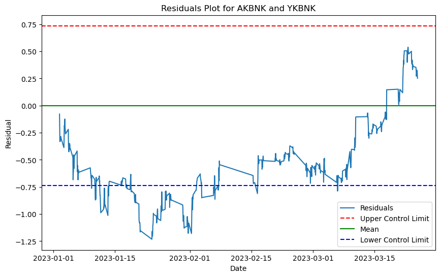

```python
stock1 = 'AKBNK'
stock2 = 'YKBNK'

new_model, new_control_limits = time_series_analysis(stock_data, stock1, stock2)
new_residuals, new_filtered_data = calculate_residuals(stock_data, new_model, '2023-01-01', '2023-03-31')
plot_residuals_with_control_limits(new_residuals, new_filtered_data, new_control_limits)
```

```python
# Display signals
new_trading_signals = generate_trading_signals(new_filtered_data, new_residuals, new_control_limits)
print(f"{'Date':<12} {'Hour':<8} {'AKBNK Price':<12} {'AKBNK Decision':<15} {'YKBNK Price':<12} {'YKBNK Decision'}")
for signal in new_trading_signals:
    date_str = signal[0].date().strftime('%Y-%m-%d')
    time_str = signal[0].time().strftime('%H:%M:%S')
    print(f"{date_str:<12} {time_str:<8} {signal[1]:<12.2f} {signal[2]:<15} {signal[3]:<12.2f} {signal[4]}")
```

```
Date         Hour     AKBNK Price  AKBNK Decision  YKBNK Price  YKBNK Decision
2023-01-09   16:00:00 16.29        SELL            9.25         BUY
2023-01-10   12:00:00 16.38        SELL            9.23         BUY
2023-01-10   13:00:00 16.30        SELL            9.15         BUY
2023-01-10   14:00:00 16.17        SELL            9.12         BUY
2023-01-10   15:00:00 16.29        SELL            9.15         BUY
2023-01-10   16:00:00 15.87        SELL            8.88         BUY
2023-01-11   13:00:00 15.21        SELL            8.50         BUY
2023-01-11   14:00:00 14.90        SELL            8.23         BUY
2023-01-11   15:00:00 15.10        SELL            8.37         BUY
2023-01-11   16:00:00 14.93        SELL            8.20         BUY
2023-01-11   17:00:00 14.71        SELL            7.98         BUY
2023-01-11   18:00:00 14.61        SELL            7.87         BUY
2023-01-12   09:00:00 14.98        SELL            8.16         BUY
2023-01-12   10:00:00 14.94        SELL            8.16         BUY
2023-01-12   11:00:00 15.01        SELL            8.20         BUY
2023-01-12   12:00:00 14.54        SELL            7.96         BUY
2023-01-12   13:00:00 14.29        SELL            7.81         BUY
2023-01-12   14:00:00 14.41        SELL            7.97         BUY
2023-01-12   15:00:00 14.74        SELL            8.10         BUY
2023-01-12   16:00:00 14.95        SELL            8.18         BUY
2023-01-12   17:00:00 15.07        SELL            8.25         BUY
2023-01-12   18:00:00 15.11        SELL            8.29         BUY
2023-01-13   09:00:00 15.06        SELL            8.16         BUY
2023-01-13   10:00:00 15.28        SELL            8.54         BUY
2023-01-13   11:00:00 15.24        SELL            8.55         BUY
2023-01-13   12:00:00 15.30        SELL            8.50         BUY
2023-01-13   13:00:00 15.21        SELL            8.48         BUY
2023-01-13   14:00:00 15.12        SELL            8.47         BUY
2023-01-17   12:00:00 15.76        SELL            8.90         BUY
2023-01-17   13:00:00 15.73        SELL            8.87         BUY
2023-01-17   14:00:00 15.72        SELL            8.87         BUY
2023-01-17   16:00:00 16.05        SELL            9.10         BUY
2023-01-17   17:00:00 15.87        SELL            8.97         BUY
2023-01-17   18:00:00 15.89        SELL            8.97         BUY
2023-01-18   09:00:00 15.92        SELL            8.98         BUY
2023-01-18   10:00:00 16.13        SELL            9.13         BUY
2023-01-18   11:00:00 16.16        SELL            9.18         BUY
2023-01-18   16:00:00 15.70        SELL            8.82         BUY
2023-01-18   17:00:00 15.72        SELL            8.83         BUY
```

[output cut: 108 more lines]

```
2023-02-03   18:00:00 14.98        SELL            8.27         BUY
2023-02-06   09:00:00 14.53        SELL            7.98         BUY
2023-02-06   10:00:00 14.54        SELL            8.07         BUY
2023-02-06   11:00:00 14.69        SELL            8.15         BUY
2023-02-06   12:00:00 14.83        SELL            8.21         BUY
2023-02-06   13:00:00 14.48        SELL            8.01         BUY
2023-02-06   17:00:00 14.71        SELL            8.07         BUY
2023-02-06   18:00:00 14.70        SELL            8.14         BUY
2023-02-07   09:00:00 14.63        SELL            8.14         BUY
2023-02-07   10:00:00 14.43        SELL            7.99         BUY
2023-02-07   11:00:00 14.07        SELL            7.72         BUY
2023-02-07   12:00:00 13.92        SELL            7.65         BUY
2023-02-07   13:00:00 14.01        SELL            7.70         BUY
2023-02-16   09:00:00 15.79        SELL            8.86         BUY
2023-03-06   14:00:00 16.80        SELL            9.57         BUY
```

```python
initial_capital = 100000  # 100,000₺ initial capital
profit_or_loss = simulate_trading(new_trading_signals, initial_capital)

print(f"Profit or Loss at the end of the simulation: {profit_or_loss}₺")
```

```
Profit or Loss at the end of the simulation: 3468.9290000000037₺
```

# Discussion

Task 1 is easy to understand and to implement. We use linear regression for task 1 which relies on the relationship between two stocks and use residuals to identify the trading opportunities. Since this method is simpler, it is faster to compute. So, we can use this method for a long time duration, which we have more data, and for the situations where computational resources are limited. If the relationship between the pair of stocks is stable over time, this strategy can be quite effective. However, this method assumes that the variance of the residuals is constant over time, which may not hold always. Also, financial markets are complex, and a simple linear relationship might not capture all the dynamics between the paired stocks. It does not account for changes in the relationship between the stocks over time.

Finally, the basic strategy is suitable for less volatile markets where the pair's price relationship is stable and linear over time. It's ideal for traders looking for a straightforward, easy-to-implement strategy. On the other hand, the advanced strategy is better suited for markets where stock relationships are more dynamic and complex.

# Conclusion